# Fitting a cross-lagged panel model

Sophie W. Berkhout

5-10-2026

### Data set

Data from Van Eersel et al. (2025) made available through DataverseNL. It contains data of employees facing job loss on hours spent job searching and job loss grief at three waves.

The variables in the data set:

-id: id of participant -x1-3: planned job search hours (1 = 0 hours; 2 = more than 0 but less than 1 hour; 3 = 1 to 5 hours; 4 = 5 to 10 hours; 5 = 10 to 20 hours; 6 = 20 hours or more) -y1-3: pre-job loss grief sum score of two times scaled 1-5 (so sum score is between 2-10)

```
dat <- read.csv("jobsearchgrief.csv")
```

### Descriptives

[output not shown]

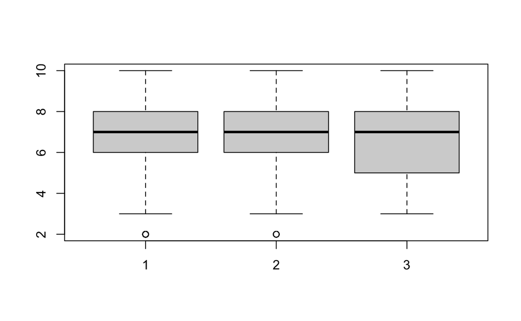

Compute the mean per person across waves for both $x$ and $y$. Do people differ a lot?

```
# your code here
```

### Fit the CLPM

Specify the cross-lagged panel model using `lavaan`. To do this, you need to create a character string with `lavaan` code. I already filled in the specification of the first wave to the second wave and the covariances. You only need to add the effects of the second wave to the third wave.

[output not shown]

[output not shown]

lavaan 0.7-2 ended normally after 49 iterations

Estimator ML Optimization method NLMINB Number of model parameters 23

```
                                              Used       Total
```

Number of observations 420 421 Number of missing patterns 5

Model Test User Model:

Test statistic 11.501 Degrees of freedom 4 P-value (Chi-square) 0.021

Parameter Estimates:

Standard errors Standard Information Observed Observed information based on Hessian

Regressions: Estimate Std.Err z-value P(>|z|) y2 ~  
y1 0.545 0.050 10.790 0.000 x1 -0.109 0.096 -1.135 0.256 y3 ~  
y2 0.678 0.061 11.123 0.000 x2 -0.240 0.096 -2.510 0.012 x2 ~  
y1 0.015 0.037 0.410 0.682 x1 0.604 0.070 8.586 0.000 x3 ~  
y2 -0.095 0.053 -1.782 0.075 x2 0.518 0.082 6.318 0.000

Covariances: Estimate Std.Err z-value P(>|z|) y1  
x1 -0.057 0.110 -0.521 0.602 .y2  
.x2 -0.001 0.100 -0.011 0.992 .y3  
.x3 0.083 0.112 0.740 0.459

Intercepts: Estimate Std.Err z-value P(>|z|) .y2 3.327 0.485 6.860 0.000 .y3 2.723 0.499 5.459 0.000 .x2 0.852 0.354 2.409 0.016 .x3 1.692 0.433 3.911 0.000 y1 6.902 0.092 74.727 0.000 x1 2.872 0.058 49.487 0.000

Variances: Estimate Std.Err z-value P(>|z|) .y2 1.963 0.195 10.090 0.000 .y3 1.341 0.183 7.332 0.000 .x2 1.043 0.103 10.103 0.000 .x3 1.011 0.137 7.389 0.000 y1 3.583 0.247 14.491 0.000 x1 1.398 0.097 14.405 0.000

[output not shown]

- Which regression coefficents are significant?
- What standardized cross-lagged effect is the strongest?

You can also specify the CLPM with latent mean centering (the alternative formulation). This way, the intercepts will represent the means of the variables. The regression coefficients should remain the same.

```
summary(fit_CLPM_c)
```

```
lavaan 0.7-2 ended normally after 47 iterations

  Estimator                                         ML
  Optimization method                           NLMINB
  Number of model parameters                        23

                                                  Used       Total
  Number of observations                           420         421
  Number of missing patterns                         5

Model Test User Model:

  Test statistic                                11.501
  Degrees of freedom                                 4
  P-value (Chi-square)                           0.021

Parameter Estimates:

  Standard errors                             Standard
  Information                                 Observed
  Observed information based on                Hessian

Latent Variables:
                   Estimate  Std.Err  z-value  P(>|z|)
  wx1 =~
    x1                1.000
  wx2 =~
    x2                1.000
  wx3 =~
    x3                1.000
  wy1 =~
    y1                1.000
  wy2 =~
    y2                1.000
  wy3 =~
    y3                1.000

Regressions:
                   Estimate  Std.Err  z-value  P(>|z|)
  wx2 ~
```

[output cut: 29 more lines]

```

Variances:
                   Estimate  Std.Err  z-value  P(>|z|)
   .x1                0.000
   .x2                0.000
   .x3                0.000
   .y1                0.000
   .y2                0.000
   .y3                0.000
   .wx3               1.011    0.137    7.389    0.000
    wx1               1.398    0.097   14.405    0.000
   .wx2               1.043    0.103   10.103    0.000
    wy1               3.583    0.247   14.491    0.000
   .wy2               1.963    0.195   10.090    0.000
   .wy3               1.341    0.183    7.332    0.000
```

Are the intercepts similar the observed means?

### References

Janske van Eersel; Inge Hulshof; Miriam I. Wickham; Geert Smid; Paul Boelen, 2025, “Replication Data for: Reciprocal relations between job loss-related grief reactions and quality of job search behaviour: A cross-lagged analysis”, https://doi.org/10.34894/1B1INC, DataverseNL, V1